# Developing an AI application

Going forward, AI algorithms will be incorporated into more and more everyday applications. For example, you might want to include an image classifier in a smart phone app. To do this, you'd use a deep learning model trained on hundreds of thousands of images as part of the overall application architecture. A large part of software development in the future will be using these types of models as common parts of applications.

The project is broken down into multiple steps:

- Load and preprocess the image dataset
- Train the image classifier on your dataset
- Use the trained classifier to predict image content

We'll lead you through each part which you'll implement in Python.

When you've completed this project, you'll have an application that can be trained on any set of labeled images. Here your network will be learning about flowers and end up as a command line application. But, what you do with your new skills depends on your imagination and effort in building a dataset. For example, imagine an app where you take a picture of a car, it tells you what the make and model is, then looks up information about it. Go build your own dataset and make something new.

First up is importing the packages you'll need. It's good practice to keep all the imports at the beginning of your code. As you work through this notebook and find you need to import a package, make sure to add the import up here.

```python
# Imports here

import numpy as np
import torch
from torch import nn
import matplotlib.pyplot as plt
import torchvision.datasets as datasets
import torchvision.transforms as transforms
from torchvision.transforms import ToTensor
import torchvision.models as models
from torch import optim
import json
import itertools
from PIL import Image
import glob, os
%matplotlib inline
import seaborn as sns
```

## Load the data

Here you'll use `torchvision` to load the data ([documentation](http://pytorch.org/docs/0.3.0/torchvision/index.html)). The data should be included alongside this notebook, otherwise you can [download it here](https://s3.amazonaws.com/content.udacity-data.com/nd089/flower_data.tar.gz).

If you do not find the `flowers/` dataset in the current directory, **/workspace/home/aipnd-project/**, you can download it using the following commands.

```
!wget 'https://s3.amazonaws.com/content.udacity-data.com/nd089/flower_data.tar.gz'
!unlink flowers
!mkdir flowers && tar -xzf flower_data.tar.gz -C flowers
```

```python
!wget 'https://s3.amazonaws.com/content.udacity-data.com/nd089/flower_data.tar.gz'

#!unlink flowers
!mkdir flowers && tar -xzf flower_data.tar.gz -C flowers
```

```
--2023-08-18 01:57:08--  https://s3.amazonaws.com/content.udacity-data.com/nd089/flower_data.tar.gz
Resolving s3.amazonaws.com (s3.amazonaws.com)... 52.216.168.157, 52.217.201.144, 52.216.9.125, ...
Connecting to s3.amazonaws.com (s3.amazonaws.com)|52.216.168.157|:443... connected.
HTTP request sent, awaiting response... 200 OK
Length: 344873452 (329M) [application/x-gzip]
Saving to: ‘flower_data.tar.gz’

flower_data.tar.gz  100%[===================>] 328.90M  33.9MB/s    in 10s

2023-08-18 01:57:19 (32.0 MB/s) - ‘flower_data.tar.gz’ saved [344873452/344873452]
```

## Data Description

The dataset is split into three parts, training, validation, and testing. For the training, you'll want to apply transformations such as random scaling, cropping, and flipping. This will help the network generalize leading to better performance. You'll also need to make sure the input data is resized to 224x224 pixels as required by the pre-trained networks.

The validation and testing sets are used to measure the model's performance on data it hasn't seen yet. For this you don't want any scaling or rotation transformations, but you'll need to resize then crop the images to the appropriate size.

The pre-trained networks you'll use were trained on the ImageNet dataset where each color channel was normalized separately. For all three sets you'll need to normalize the means and standard deviations of the images to what the network expects. For the means, it's `[0.485, 0.456, 0.406]` and for the standard deviations `[0.229, 0.224, 0.225]`, calculated from the ImageNet images. These values will shift each color channel to be centered at 0 and range from -1 to 1.

```python
data_dir = 'flowers'
train_dir = data_dir + '/train'
valid_dir = data_dir + '/valid'
test_dir = data_dir + '/test'
```

```python
# Since can't use GPU per workspace technical issues that is not working at my Udacity Workspace need to reduce data set size
# thus tried to slice a portion of the training set yet the idea did not worked

smalltrain = 'flowers/train[:500]'
smalltrain
```

```
'flowers/train[:500]'
```

### Splitting to-do actions for a cleaner implementation step by step

```python
# TODO: Define your transforms for the training, validation, and testing sets

data_transforms = transforms.Compose([
    transforms.Resize((224, 224)),
    transforms.ToTensor(),
    transforms.RandomHorizontalFlip(),
    transforms.Normalize([0.485, 0.456, 0.406], [0.229, 0.224, 0.225])
])
```

```python
# TODO: Load the datasets with ImageFolder

image_datasets = datasets.ImageFolder(data_dir)

img = image_datasets.imgs

print(f"Total number of images: {len(img)}")
print(f"Total number of categories: {len(image_datasets.classes)}")
```

```
Total number of images: 8189
Total number of categories: 3
```

```python
# Since not able to reduce the size of training data set will then just use Test for training and Validation for validations
'''
trainset = datasets.ImageFolder(test_dir, transform=data_transforms)

trimg = trainset.imgs

print(f"Training set number of images: {len(trimg)}")
print(f"Training set number of categories: {len(trainset.classes)}")
print()
'''
```

[output not shown]

```python
# So here I create a new variable to hold the test folder data that will be used for training

small_trainset = datasets.ImageFolder(test_dir, transform=data_transforms)

tstimg = small_trainset.imgs

print(f"Training set number of images: {len(tstimg)}")
print(f"Training set number of categories: {len(small_trainset.classes)}")
print()
```

```
Training set number of images: 819
Training set number of categories: 102
```

```python
small_trainset
```

[output not shown]

```python
# Validation dataset remains as such for validations

validationset = datasets.ImageFolder(valid_dir, transform=data_transforms)

valimg = validationset.imgs

print(f"Training set number of images: {len(valimg)}")
print(f"Training set number of categories: {len(validationset.classes)}")
print()
```

```
Training set number of images: 818
Training set number of categories: 102
```

```python
validationset
```

[output not shown]

```python
# TODO: Using the image datasets and the trainforms, define the dataloaders
# dataloaders =

trainloader = torch.utils.data.DataLoader(small_trainset, batch_size=64, shuffle=True)

# Dismissing the testloader as it will serve no purpuse for the size reduction to be able to train without the GPU
#testloader = torch.utils.data.DataLoader(testset, batch_size=64)

validationloader = torch.utils.data.DataLoader(validationset, batch_size=64)

class_to_idx = small_trainset.class_to_idx

print()
print("MVP")
```

```
MVP
```

### Label mapping

You'll also need to load in a mapping from category label to category name. You can find this in the file `cat_to_name.json`. It's a JSON object which you can read in with the [`json` module](https://docs.python.org/2/library/json.html). This will give you a dictionary mapping the integer encoded categories to the actual names of the flowers.

```python
# As using Google Colab have to create the dict manually instead of pulling it from the json file as not at this folder

cat_dict = {"21": "fire lily", "3": "canterbury bells", "45": "bolero deep blue", "1": "pink primrose", "34": "mexican aster", "27": "prince of wales feathers", "7": "moon orchid", "16": "globe-flower", "25": "grape hyacinth", "26": "corn poppy", "79": "toad lily", "39": "siam tulip", "24": "red ginger", "67": "spring crocus", "35": "alpine sea holly", "32": "garden phlox", "10": "globe thistle", "6": "tiger lily", "93": "ball moss", "33": "love in the mist", "9": "monkshood", "102": "blackberry lily", "14": "spear thistle", "19": "balloon flower", "100": "blanket flower", "13": "king protea", "49": "oxeye daisy", "15": "yellow iris", "61": "cautleya spicata", "31": "carnation", "64": "silverbush", "68": "bearded iris", "63": "black-eyed susan", "69": "windflower", "62": "japanese anemone", "20": "giant white arum lily", "38": "great masterwort", "4": "sweet pea", "86": "tree mallow", "101": "trumpet creeper", "42": "daffodil", "22": "pincushion flower", "2": "hard-leaved pocket orchid", "54": "sunflower", "66": "osteospermum", "70": "tree poppy", "85": "desert-rose", "99": "bromelia", "87": "magnolia", "5": "english marigold", "92": "bee balm", "28": "stemless gentian", "97": "mallow", "57": "gaura", "40": "lenten rose", "47": "marigold", "59": "orange dahlia", "48": "buttercup", "55": "pelargonium", "36": "ruby-lipped cattleya", "91": "hippeastrum", "29": "artichoke", "71": "gazania", "90": "canna lily", "18": "peruvian lily", "98": "mexican petunia", "8": "bird of paradise", "30": "sweet william", "17": "purple coneflower", "52": "wild pansy", "84": "columbine", "12": "colt's foot", "11": "snapdragon", "96": "camellia", "23": "fritillary", "50": "common dandelion", "44": "poinsettia", "53": "primula", "72": "azalea", "65": "californian poppy", "80": "anthurium", "76": "morning glory", "37": "cape flower", "56": "bishop of llandaff", "60": "pink-yellow dahlia", "82": "clematis", "58": "geranium", "75": "thorn apple", "41": "barbeton daisy", "95": "bougainvillea", "43": "sword lily", "83": "hibiscus", "78": "lotus lotus", "88": "cyclamen", "94": "foxglove", "81": "frangipani", "74": "rose", "89": "watercress", "73": "water lily", "46": "wallflower", "77": "passion flower", "51": "petunia"}
```

```python
#with open('cat_to_name.json', 'r') as f:
    #cat_to_name = json.load(f)

# Keeping the same variable name and assigning the dictionary which is the equivalent of having pulled the json file
cat_to_name = cat_dict
```

```python
# Confirm proper dictionary with numeric labels equivalent in name label

print(f'The first 3 pairs are: {dict(itertools.islice(cat_to_name.items(), 3))}')
```

```
The first 3 pairs are: {'21': 'fire lily', '3': 'canterbury bells', '45': 'bolero deep blue'}
```

```python
# OR

cat_to_name['99']
```

```
'bromelia'
```

# Building and training the classifier

Now that the data is ready, it's time to build and train the classifier. As usual, you should use one of the pretrained models from `torchvision.models` to get the image features. Build and train a new feed-forward classifier using those features.

We're going to leave this part up to you. Refer to [the rubric](https://review.udacity.com/#!/rubrics/1663/view) for guidance on successfully completing this section. Things you'll need to do:

- Load a [pre-trained network](http://pytorch.org/docs/master/torchvision/models.html) (If you need a starting point, the VGG networks work great and are straightforward to use)
- Define a new, untrained feed-forward network as a classifier, using ReLU activations and dropout
- Train the classifier layers using backpropagation using the pre-trained network to get the features
- Track the loss and accuracy on the validation set to determine the best hyperparameters

We've left a cell open for you below, but use as many as you need. Our advice is to break the problem up into smaller parts you can run separately. Check that each part is doing what you expect, then move on to the next. You'll likely find that as you work through each part, you'll need to go back and modify your previous code. This is totally normal!

When training make sure you're updating only the weights of the feed-forward network. You should be able to get the validation accuracy above 70% if you build everything right. Make sure to try different hyperparameters (learning rate, units in the classifier, epochs, etc) to find the best model. Save those hyperparameters to use as default values in the next part of the project.

One last important tip if you're using the workspace to run your code: To avoid having your workspace disconnect during the long-running tasks in this notebook, please read in the earlier page in this lesson called Intro to GPU Workspaces about Keeping Your Session Active. You'll want to include code from the workspace_utils.py module.

## Note for Workspace users:

If your network is over 1 GB when saved as a checkpoint, there might be issues with saving backups in your workspace. Typically this happens with wide dense layers after the convolutional layers. If your saved checkpoint is larger than 1 GB (you can open a terminal and check with `ls -lh`), you should reduce the size of your hidden layers and train again.

```python
# TODO: Build and train your network
```

```python
# 1. Load a pre-train network

# Initial models considerations
#model = torch.hub.load('facebookresearch/pytorchvideo', 'slowfast_r50', pretrained=True)
#torchvision.models.vgg16(*, weights: Optional[VGG16_Weights] = None, progress: bool = True, **kwargs: Any) → VGG
#model = torch.hub.load("pytorch/vision", "resnet50", weights="IMAGENET1K_V2")
#OR

# Decided on this model:

mvpmodel = models.vgg16(pretrained = True)
```

```python
mvpmodel
```

```
VGG(
  (features): Sequential(
    (0): Conv2d(3, 64, kernel_size=(3, 3), stride=(1, 1), padding=(1, 1))
    (1): ReLU(inplace=True)
    (2): Conv2d(64, 64, kernel_size=(3, 3), stride=(1, 1), padding=(1, 1))
    (3): ReLU(inplace=True)
    (4): MaxPool2d(kernel_size=2, stride=2, padding=0, dilation=1, ceil_mode=False)
    (5): Conv2d(64, 128, kernel_size=(3, 3), stride=(1, 1), padding=(1, 1))
    (6): ReLU(inplace=True)
    (7): Conv2d(128, 128, kernel_size=(3, 3), stride=(1, 1), padding=(1, 1))
    (8): ReLU(inplace=True)
    (9): MaxPool2d(kernel_size=2, stride=2, padding=0, dilation=1, ceil_mode=False)
    (10): Conv2d(128, 256, kernel_size=(3, 3), stride=(1, 1), padding=(1, 1))
    (11): ReLU(inplace=True)
    (12): Conv2d(256, 256, kernel_size=(3, 3), stride=(1, 1), padding=(1, 1))
    (13): ReLU(inplace=True)
    (14): Conv2d(256, 256, kernel_size=(3, 3), stride=(1, 1), padding=(1, 1))
    (15): ReLU(inplace=True)
    (16): MaxPool2d(kernel_size=2, stride=2, padding=0, dilation=1, ceil_mode=False)
    (17): Conv2d(256, 512, kernel_size=(3, 3), stride=(1, 1), padding=(1, 1))
    (18): ReLU(inplace=True)
    (19): Conv2d(512, 512, kernel_size=(3, 3), stride=(1, 1), padding=(1, 1))
    (20): ReLU(inplace=True)
    (21): Conv2d(512, 512, kernel_size=(3, 3), stride=(1, 1), padding=(1, 1))
    (22): ReLU(inplace=True)
    (23): MaxPool2d(kernel_size=2, stride=2, padding=0, dilation=1, ceil_mode=False)
    (24): Conv2d(512, 512, kernel_size=(3, 3), stride=(1, 1), padding=(1, 1))
    (25): ReLU(inplace=True)
    (26): Conv2d(512, 512, kernel_size=(3, 3), stride=(1, 1), padding=(1, 1))
    (27): ReLU(inplace=True)
    (28): Conv2d(512, 512, kernel_size=(3, 3), stride=(1, 1), padding=(1, 1))
    (29): ReLU(inplace=True)
    (30): MaxPool2d(kernel_size=2, stride=2, padding=0, dilation=1, ceil_mode=False)
  )
  (avgpool): AdaptiveAvgPool2d(output_size=(7, 7))
  (classifier): Sequential(
    (0): Linear(in_features=25088, out_features=4096, bias=True)
    (1): ReLU(inplace=True)
    (2): Dropout(p=0.5, inplace=False)
    (3): Linear(in_features=4096, out_features=4096, bias=True)
    (4): ReLU(inplace=True)
    (5): Dropout(p=0.5, inplace=False)
    (6): Linear(in_features=4096, out_features=1000, bias=True)
  )
)
```

```python
# 2. Define a new, untrained feed-forward network as a classifier, using ReLU activations and dropout

# Here I turn off gradients for my model
for param in mvpmodel.parameters():
    param.requires_grad = False

# Here I customize the classifier to my needs
classifier = nn.Sequential(nn.Linear(25088, 6552),
                                 nn.ReLU(),
                                 nn.Dropout(0.2),
                                 nn.Linear(6552, 102),
                                 nn.LogSoftmax(dim=1))
mvpmodel.classifier = classifier
```

```python
# Here I set the criteria for loss

criterion = nn.NLLLoss()
```

```python
# Here I set the optimizer with learning rate of .003

optimizer = optim.Adam(mvpmodel.classifier.parameters(), lr=0.003)
```

```python
# Here I follow the learning advise to leverage on gpu when possible

device = torch.device("cuda" if torch.cuda.is_available() else "cpu")
```

```python
# 3. Train the classifier layers using backpropagation using the pre-trained network to get the features

# .....................................................
# Mi Ago.16.2023
# .....................................................

# Here I set the total number of epochs (Epoch is 1 iteration where the model sees the whole training set to update its weights)
total_epochs = 1
steps = 0
training_loss = 0
train_accuracy = 0

# Here I set the epochs
for epoch in range(total_epochs):

    # Here I pull the images and labels from the trainloader object
    for images, labels in trainloader:

        # Here setting the steps for counting sake
        steps += 1

        # Here I enable both images and labels to be processed by GPU if available
        images, labels = images.to(device), labels.to(device)


        # FORWARD PROPAGATION

        # Here I make the forward propagation asking the model to predict label for images on the trainloader batch
        logps = mvpmodel(images)
        # Leave the following line in case is needed if problem related to cuda run
        #logps = mymodel.cuda()(images)

        # Here I log the loss function among the predictions of the fowards propagation against the labels
        loss = criterion(logps, labels)


        # BACKPROPAGATION

        # First clear out the gradients at each pass
        optimizer.zero_grad()

        # Here I get the gradient of the loss with respect to each weight
        loss.backward()

        # Here I request the weights to be updated
        optimizer.step()

        # Here I log the loss from the training
        training_loss += loss.item()


        # Calculate accuracy for the training
        pst = torch.exp(logps)
        top_pt, top_classt = pst.topk(1, dim=1)
        equalst = top_classt == labels.view(*top_classt.shape)
        train_accuracy += torch.mean(equalst.type(torch.FloatTensor)).item()

        # Now evaluate outcomes against the validation set
        validation_loss = 0
        validation_accuracy = 0
        mvpmodel.eval()
        with torch.no_grad():
            for inputs, labels in validationloader:
                inputs, labels = inputs.to(device), labels.to(device)
                logps = mvpmodel.forward(inputs)
                batch_loss = criterion(logps, labels)

                validation_loss += batch_loss.item()

                # Calculate accuracy
                ps = torch.exp(logps)
                top_p, top_class = ps.topk(1, dim=1)
                equals = top_class == labels.view(*top_class.shape)
                validation_accuracy += torch.mean(equals.type(torch.FloatTensor)).item()

        print(f"Epoch {epoch+1}/{total_epochs} at step {steps}: "
              f"Train loss: {training_loss/len(trainloader)   :.3f}, "
              f"Validation loss: {validation_loss/len(validationloader)   :.3f}. ")
        print(f"Epoch {epoch+1}/{total_epochs} at step {steps}: "
              f"Train accuracy: {train_accuracy/64:.3f}, "
              f"Validation accuracy: {validation_accuracy/len(validationloader):.3f}.")
        print("")

        training_loss = 0
        mvpmodel.train()
```

[output not shown]

```python
# Testing ... outcome matches the one evaluated during the traing with validation phase at 19.2% accuracy given
# just 1 epoch and a much smaller data set but best I can do without using GPU that is not working at my Udacity Workspace

# TODO: Do validation on the test set

# Here I set the model at eval mode
mvpmodel.eval()

# Here I set the accuracy at initial value of zero
test_accuracy = 0

# Here the loop begins to get pictures and labels from the test set
for pics, labels in validationloader:

    # Here I seek to leverage on GPU
    pics, labels = pics.to(device), labels.to(device)

    # Here we request the prediction
    predictions = mvpmodel(pics)

    # Class with the highest probability is our predicted class
    compare = (labels.data == predictions.max(1)[1])

    # Here accuracy means the number of correct predictions by all predictions
    test_accuracy += compare.type_as(torch.FloatTensor()).mean()

print(f"Overall model test accuracy is: {test_accuracy/len(validationloader):.3f}")
```

[output not shown]

## Save the checkpoint

Now that your network is trained, save the model so you can load it later for making predictions. You probably want to save other things such as the mapping of classes to indices which you get from one of the image datasets: `image_datasets['train'].class_to_idx`. You can attach this to the model as an attribute which makes inference easier later on.

`model.class_to_idx = image_datasets['train'].class_to_idx`

Remember that you'll want to completely rebuild the model later so you can use it for inference. Make sure to include any information you need in the checkpoint. If you want to load the model and keep training, you'll want to save the number of epochs as well as the optimizer state, `optimizer.state_dict`. You'll likely want to use this trained model in the next part of the project, so best to save it now.

```python
# Step needed as using Google Colab since best I can do without using GPU that is not working at my Udacity Workspace

from google.colab import drive
drive.mount('/content/drive')
```

```python
# TODO: Save the checkpoint ... at Google Drive

# With new model training by 8.16.2023 PM with original form into several files

# First capture the class to index into the trained model
mvpmodel.class_to_idx = small_trainset.class_to_idx

# Then go ahead and save all changes into several .pth file at Drive
torch.save(mvpmodel, '/content/drive/My Drive/newmvpmodel.pth')
torch.save(mvpmodel.state_dict(), '/content/drive/My Drive/newmvpmodelSD.pth')
torch.save(mvpmodel.class_to_idx, '/content/drive/My Drive/newmvpmodelCtI.pth')
```

```python
# A different way to save the checkpoint

# With new model training by 8.16.2023 PM with compact form into a single file saved

# First capture the class to index into the trained model
mvpmodel.class_to_idx = small_trainset.class_to_idx

# Then go ahead and save all changes into a single .pth file at Drive
torch.save({'arch': 'mvpmodel',
            'state_dict': mvpmodel.state_dict(),
            'class_to_idx': mvpmodel.class_to_idx},
            '/content/drive/My Drive/rodmvpcombo.pth')
```

```python
# And yet different way to save the checkpoint

# First capture the class to index into the trained model
#  Without this line I get: "AttributeError: 'VGG' object has no attribute 'class_to_idx'"
#mvpmodel.class_to_idx = small_trainset.class_to_idx

# Now save the checkpoint
mvpcheckpoint = {'model': mvpmodel,
                'classifier': mvpmodel.classifier,
                'state_dict': mvpmodel.state_dict(),
                'class_to_idx': mvpmodel.class_to_idx
                }

torch.save(mvpcheckpoint, '/content/drive/My Drive/mvpwtf.pth')
```

## Loading the checkpoint

At this point it's good to write a function that can load a checkpoint and rebuild the model. That way you can come back to this project and keep working on it without having to retrain the network.

# New Section

```python
# Using the original saved form adding the class to index that was missing in the beginning

new_mvp_saved_model = torch.load('/content/drive/My Drive/newmvpmodel.pth')
print(new_mvp_saved_model)
print("")
state_dict = torch.load('/content/drive/My Drive/newmvpmodelSD.pth')
print(state_dict.keys())
print("")
class_index = torch.load('/content/drive/My Drive/newmvpmodelCtI.pth')
print(class_index)
```

[output not shown]

```python
# Confirm that all keys are matching properly

new_mvp_saved_model.load_state_dict(state_dict)
```

```
<All keys matched successfully>
```

```python
# Make a model evaluation to confirm the inputs and outputs

new_mvp_saved_model.eval()
```

```
VGG(
  (features): Sequential(
    (0): Conv2d(3, 64, kernel_size=(3, 3), stride=(1, 1), padding=(1, 1))
    (1): ReLU(inplace=True)
    (2): Conv2d(64, 64, kernel_size=(3, 3), stride=(1, 1), padding=(1, 1))
    (3): ReLU(inplace=True)
    (4): MaxPool2d(kernel_size=2, stride=2, padding=0, dilation=1, ceil_mode=False)
    (5): Conv2d(64, 128, kernel_size=(3, 3), stride=(1, 1), padding=(1, 1))
    (6): ReLU(inplace=True)
    (7): Conv2d(128, 128, kernel_size=(3, 3), stride=(1, 1), padding=(1, 1))
    (8): ReLU(inplace=True)
    (9): MaxPool2d(kernel_size=2, stride=2, padding=0, dilation=1, ceil_mode=False)
    (10): Conv2d(128, 256, kernel_size=(3, 3), stride=(1, 1), padding=(1, 1))
    (11): ReLU(inplace=True)
    (12): Conv2d(256, 256, kernel_size=(3, 3), stride=(1, 1), padding=(1, 1))
    (13): ReLU(inplace=True)
    (14): Conv2d(256, 256, kernel_size=(3, 3), stride=(1, 1), padding=(1, 1))
    (15): ReLU(inplace=True)
    (16): MaxPool2d(kernel_size=2, stride=2, padding=0, dilation=1, ceil_mode=False)
    (17): Conv2d(256, 512, kernel_size=(3, 3), stride=(1, 1), padding=(1, 1))
    (18): ReLU(inplace=True)
    (19): Conv2d(512, 512, kernel_size=(3, 3), stride=(1, 1), padding=(1, 1))
    (20): ReLU(inplace=True)
    (21): Conv2d(512, 512, kernel_size=(3, 3), stride=(1, 1), padding=(1, 1))
    (22): ReLU(inplace=True)
    (23): MaxPool2d(kernel_size=2, stride=2, padding=0, dilation=1, ceil_mode=False)
    (24): Conv2d(512, 512, kernel_size=(3, 3), stride=(1, 1), padding=(1, 1))
    (25): ReLU(inplace=True)
    (26): Conv2d(512, 512, kernel_size=(3, 3), stride=(1, 1), padding=(1, 1))
    (27): ReLU(inplace=True)
    (28): Conv2d(512, 512, kernel_size=(3, 3), stride=(1, 1), padding=(1, 1))
    (29): ReLU(inplace=True)
    (30): MaxPool2d(kernel_size=2, stride=2, padding=0, dilation=1, ceil_mode=False)
  )
  (avgpool): AdaptiveAvgPool2d(output_size=(7, 7))
  (classifier): Sequential(
    (0): Linear(in_features=25088, out_features=6552, bias=True)
    (1): ReLU()
    (2): Dropout(p=0.2, inplace=False)
    (3): Linear(in_features=6552, out_features=102, bias=True)
    (4): LogSoftmax(dim=1)
  )
)
```

# Inference for classification

Now you'll write a function to use a trained network for inference. That is, you'll pass an image into the network and predict the class of the flower in the image. Write a function called `predict` that takes an image and a model, then returns the top $K$ most likely classes along with the probabilities. It should look like

```
probs, classes = predict(image_path, model)
print(probs)
print(classes)
> [ 0.01558163  0.01541934  0.01452626  0.01443549  0.01407339]
> ['70', '3', '45', '62', '55']
```

First you'll need to handle processing the input image such that it can be used in your network.

## Image Preprocessing

You'll want to use `PIL` to load the image ([documentation](https://pillow.readthedocs.io/en/latest/reference/Image.html)). It's best to write a function that preprocesses the image so it can be used as input for the model. This function should process the images in the same manner used for training.

First, resize the images where the shortest side is 256 pixels, keeping the aspect ratio. This can be done with the [`thumbnail`](http://pillow.readthedocs.io/en/3.1.x/reference/Image.html#PIL.Image.Image.thumbnail) or [`resize`](http://pillow.readthedocs.io/en/3.1.x/reference/Image.html#PIL.Image.Image.thumbnail) methods. Then you'll need to crop out the center 224x224 portion of the image.

Color channels of images are typically encoded as integers 0-255, but the model expected floats 0-1. You'll need to convert the values. It's easiest with a Numpy array, which you can get from a PIL image like so `np_image = np.array(pil_image)`.

As before, the network expects the images to be normalized in a specific way. For the means, it's `[0.485, 0.456, 0.406]` and for the standard deviations `[0.229, 0.224, 0.225]`. You'll want to subtract the means from each color channel, then divide by the standard deviation.

And finally, PyTorch expects the color channel to be the first dimension but it's the third dimension in the PIL image and Numpy array. You can reorder dimensions using [`ndarray.transpose`](https://docs.scipy.org/doc/numpy-1.13.0/reference/generated/numpy.ndarray.transpose.html). The color channel needs to be first and retain the order of the other two dimensions.

```python
# TODO: Process a PIL image for use in a PyTorch model

# Per the instructions above doing the following processing steps:

def process_image(image):
    #Scales, crops, and normalizes a PIL image for a PyTorch model,
    #returns an Numpy array

    # TODO: Process a PIL image for use in a PyTorch model

    # Here I use PIL to load the image
    image = Image.open(image)

    # Here I resize the image keeping the aspect ratio (thus cropping out the center 224x224 portion of the image)
    image = image.resize((224, 224))

    # Here I convert the values the model expected floats 0-1 ()
    image = np.array(image)

    # Here I divide since color channels of images are typically encoded as integers 0-255
    image = image / 255.0

    # Here I subtract the means from each color channel, then divide by the standard deviation.
    image = (image - [0.485, 0.456, 0.406]) / [0.229, 0.224, 0.225]

    # Here I reorder dimensions as PyTorch expects the color channel to be the first dimension  using ndarray.
    image = image.transpose((2, 0, 1))

    # Finally here I create a tensor from the numpy array as that is what I would expect as output
    return torch.from_numpy(image)

    # Optional output given that instructions request to "returns an Numpy array" then only returning the processed object which is image
    #return image
```

```python
# Now using the other function provided to validate the function above

def imshow(image, ax=None, title=None):
    """Imshow for Tensor."""
    if ax is None:
        fig, ax = plt.subplots()

    # PyTorch tensors assume the color channel is the first dimension
    # but matplotlib assumes is the third dimension
    image = image.numpy().transpose((1, 2, 0))

    # Undo preprocessing
    mean = np.array([0.485, 0.456, 0.406])
    std = np.array([0.229, 0.224, 0.225])
    image = std * image + mean

    # Image needs to be clipped between 0 and 1 or it looks like noise when displayed
    image = np.clip(image, 0, 1)

    ax.imshow(image)

    return ax
```

```python
myimage = process_image('flowers/test/1/image_06743.jpg')

path4image = 'flowers/test/1/image_06743.jpg'
```

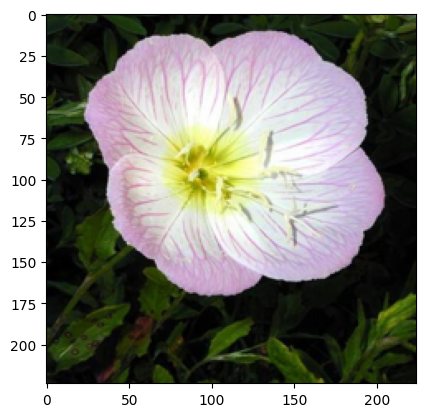

```python
# Checking the function above working

imshow(myimage);
```

## Class Prediction

Once you can get images in the correct format, it's time to write a function for making predictions with your model. A common practice is to predict the top 5 or so (usually called top-$K$) most probable classes. You'll want to calculate the class probabilities then find the $K$ largest values.

To get the top $K$ largest values in a tensor use [`x.topk(k)`](http://pytorch.org/docs/master/torch.html#torch.topk). This method returns both the highest `k` probabilities and the indices of those probabilities corresponding to the classes. You need to convert from these indices to the actual class labels using `class_to_idx` which hopefully you added to the model or from an `ImageFolder` you used to load the data (see here). Make sure to invert the dictionary so you get a mapping from index to class as well.

Again, this method should take a path to an image and a model checkpoint, then return the probabilities and classes.

```
probs, classes = predict(image_path, model)
print(probs)
print(classes)
> [ 0.01558163  0.01541934  0.01452626  0.01443549  0.01407339]
> ['70', '3', '45', '62', '55']
```

```python
# Set variable for image that will be predicted, compared, and displayed

path_to_image = 'flowers/test/99/image_07874.jpg'
```

```python
# Now the predict function

def predict(image, model, topk=5):
    idx_to_class = dict()
    top_classes = list()

    model.eval()
    # Gives input double vs bias float problem if not adding the last part
    #image = image.unsqueeze(0)
    image = image.unsqueeze(0).float()
    with torch.no_grad():
        output = model(image)
        probabilities = torch.exp(output)
        top_probabilities, top_indices = probabilities.topk(topk)
        top_probabilities = top_probabilities.squeeze().tolist()
        top_indices = top_indices.squeeze().tolist()
        idx_to_class = {value: key for key, value in model.class_to_idx.items()}
        top_classes = [idx_to_class[index] for index in top_indices]

        return top_probabilities, top_classes
```

```python
# Now set the top classes and probabilities

top_probabilities, top_classes = predict(process_image(path_to_image), new_mvp_saved_model)
print(top_probabilities)
print(top_classes)
```

```
[0.6103159785270691, 0.2132394015789032, 0.03846067935228348, 0.03565194085240364, 0.011836003512144089]
['99', '53', '73', '46', '17']
```

## Sanity Checking

You can convert from the class integer encoding to actual flower names with the `cat_to_name.json` file (should have been loaded earlier in the notebook). To show a PyTorch tensor as an image, use the `imshow` function defined above.

```python
# TODO: Display an image along with the top 5 classes
```

```python
# Creating a variable to hold the top classes names

top_class_names = [cat_to_name[class_] for class_ in top_classes]
```

```python
# Iteration to confirm the names and order top to bottom of names and probabilities

for i in range(len(top_classes)):
    print(f"{top_class_names[i]}: {top_probabilities[i]}")
```

```
bromelia: 0.6103159785270691
primula: 0.2132394015789032
water lily: 0.03846067935228348
wallflower: 0.03565194085240364
purple coneflower: 0.011836003512144089
```

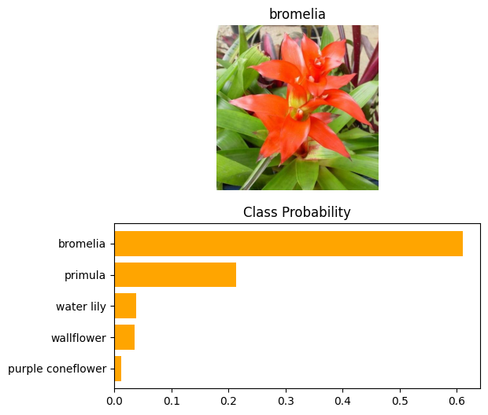

```python
# The final function to wrap everything together with a visual display

def viz(img_path, prob, classes, mapping):

    # Using PIL function to pull the path of the image
    image = Image.open(img_path)

    # Setting the plot area to hold both plots needed
    fig, (A, B) = plt.subplots(figsize=(6,6), ncols=1, nrows=2)

    # First Plot Settings that I am calling A

    # Prep work for the flower name
    flower_name = mapping[img_path.split('/')[-2]]

    # Set the title of the flower that will be displayed below it
    A.set_title(flower_name)

    # Display the visualization of the flower
    A.imshow(image)

    # Remove the axis for the image for a more neat look
    A.axis('off')


    # Second Plot Settings that I am calling B

    # Setting the y range for values
    y_pos = np.arange(len(prob))

    # Bar chart selection with inputs
    B.barh(y_pos, prob, align='center', color = 'orange');

    # Set the y labels
    B.set_yticks(y_pos)

    # Set names instead of numbers
    flower_names = top_class_names

    # Display the flower names at y labels of the bar chart
    B.set_yticklabels(flower_names)

    # This is needed to order top probability from top to buttom
    B.invert_yaxis()

    # Title for the second plot
    B.set_title('Class Probability')


# Call the function to vizualize the outcome
viz(path_to_image, top_probabilities, top_classes, cat_to_name)
```

## Reminder for Workspace users

If your network becomes very large when saved as a checkpoint, there might be issues with saving backups in your workspace. You should reduce the size of your hidden layers and train again.

We strongly encourage you to delete these large interim files and directories before navigating to another page or closing the browser tab.

```python
# TODO remove .pth files or move it to a temporary `~/opt` directory in this Workspace
```

```python
# Not applicable in my case
```